# Network Selection

**1** - Homophily- Do participants choose people who are closer to their rating

**2** - Friending vs. Unfriending - is there a difference in homophily when looking at the manipulation **3** - Choice strategyf

**4** - stickiness.

```r
des = d%>%
  group_by(id)%>%
  select(age)
```

### 1 - Values kept

Let’s first look at kept ratings for the control and the selection condition and see if they are difference

```r
r= lmer(peerRating~condition +(1|subject_id), dl); summary(r)


dfc <- summarySE(dl, measurevar="peerRating", groupvars=c("condition","elimKeep"), na.rm = T)

#dfc$elimKeep=factor(dfc$elimKeep, label = c("eliminate", "keep"))
pd <- position_dodge(0)
ggplot(dfc, aes(x=condition, y=peerRating, fill=elimKeep)) +
    geom_bar(position=position_dodge(), stat="identity", colour="black" ) +
    labs(title="")+
    guides(fill=guide_legend(title=NULL))+
    theme_bw()+
    theme(plot.title = element_text(size = rel(1.5)),
          axis.title.y = element_text(face="bold",  size=14),
          axis.text.x  = element_text( vjust=0.5, size=18),
          axis.text.y  = element_text( vjust=0.5, size=12),
          axis.title.x = element_blank()) +
  coord_cartesian(ylim=c(3, 6)) +
  ylab("Peer Rating")+
  geom_errorbar(aes(ymin=peerRating-ci, ymax=peerRating+ci),
                  width=.1,position=position_dodge(.9))
```

kept participants over time

```r
r = lmer(peerRating~scale(trial)*condition +(1|subject_id),dl);summary(r)


dfc <- summarySE(dl, measurevar="peerRating", groupvars=c("elimKeep", "trial","condition"), na.rm = T)

dfc=subset(dfc, elimKeep== "kept")

g = (ggplot(dfc,aes(x=trial, y=peerRating ,fill = condition))
  + geom_errorbar(aes(ymin=peerRating-se, ymax=peerRating+se), width=.1)
  + geom_line( aes(linetype= condition, group=condition),size = 1.2)
  +geom_point()
  #+scale_y_continuous(limits = c(3, 7))
  +theme_bw()
  +theme(legend.title=element_blank(),
         #legend.position =  "none",
         axis.title.y = element_text(  size=14),
         axis.text.x  = element_text( vjust=0.5, size=14),
         axis.text.y  = element_text( vjust=0.5, size=12),
         axis.title.x = element_text(vjust=0.5, size=14))
  +labs(title = "Kept participants as a function of trial number", x = "Trial number", y = "Ratings"));g



dfc <- summarySE(dl, measurevar="peerRating", groupvars=c("elimKeep", "trial","condition"), na.rm = T)

dfc = subset (dfc, elimKeep =="kept")

g = (ggplot(dfc,aes(x=trial, y=peerRating ,fill = condition, colour = condition))
  +stat_smooth(aes(linetype=condition, colour =condition),
              size =1.2, method='lm',fill = "grey",
              se = T, na.rm =T)
  +theme_bw()
  +theme(legend.title=element_blank(),axis.title.y = element_text(  size=14),axis.text.x  = element_text( vjust=0.5, size=14),axis.text.y  = element_text( vjust=0.5, size=12),axis.title.x = element_text(vjust=0.5, size=14))
  +labs(title = "keep as a function of trial number", x = "Trial number", y = " Keep"));g
```

### 2 - homophily

I am using the the difference between participants and the users that each participants kept vs. eliminated.

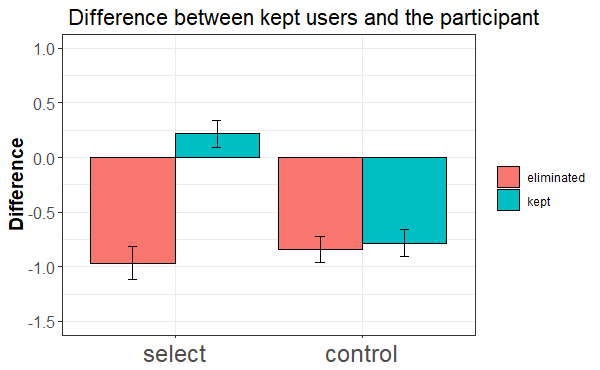

## 2 - difference in rating bewteen the conditions

```r
dlc = subset (dl, elimKeep=="kept"& condition =="select")
dlc=dlc %>%select(-condition, -elimKeep,-peerDif)

dlc =dlc %>%
  gather (rater, valueRating,-subject_id, -trial, -number)


r = lmer(valueRating~ rater +(1|subject_id),dlc);summary(r)

#get a slope per participant
model_bias= dlc%>%
  group_by(subject_id)  %>%
  do(r = lm(valueRating~ rater , data = .))%>%
  mutate(bias = r$coefficients[[2]])%>%
  select(-r)

    #models is the lms for all participants

model_rating = sl%>%
  group_by(subject_id)%>%
  do(r = lm(subject_rating~ trial , data = .))%>%
  mutate(ratingChange = r$coefficients[[2]])%>%
  select(-r)

model = left_join(model_bias,model_rating, by = "subject_id")

cor.test(model$ratingChange,model$bias)



ggplot(model, aes(x=ratingChange, y=bias)) +
    geom_point(shape=1) +
    geom_smooth()
```

### selection strategy bt trial

```r
# crate a graph in which participants within-trial order is in the x axis and the difference between their rating and the agent rating is in the y axis. (seperated by condition )
```

### 3 - comparing to various algorithms - see Vibha’s code

We look at the users that participants kept:

1. What would happen if you compared it to a random selection.
2. What would happen if you just took the 3 people closest to you.
3. What would happen if you just sampled the most liberal group.

```
[1] 5.2
Linear mixed model fit by REML t-tests use Satterthwaite approximations to
  degrees of freedom [lmerMod]
Formula: value ~ keepType + (1 | subject_id)
   Data: dStrategyCompare

REML criterion at convergence: 8732.5

Scaled residuals:
    Min      1Q  Median      3Q     Max
-3.3517 -0.6508  0.0310  0.7238  2.7842

Random effects:
 Groups     Name        Variance Std.Dev.
 subject_id (Intercept) 0.2972   0.5452
 Residual               1.9100   1.3820
Number of obs: 2480, groups:  subject_id, 31

Fixed effects:
                       Estimate Std. Error         df t value Pr(>|t|)
(Intercept)             5.04785    0.11255   44.80000  44.849  < 2e-16 ***
keepTypemeanKeptLib     0.47151    0.07849 2446.00000   6.007 2.17e-09 ***
keepTyperandKeepMean   -0.32634    0.07849 2446.00000  -4.158 3.33e-05 ***
keepTyperealKeepMean    0.30215    0.07849 2446.00000   3.849 0.000121 ***
---
Signif. codes:  0 *** 0.001 ** 0.01 * 0.05 . 0.1   1

Correlation of Fixed Effects:
            (Intr) kpTyKL kpTyprnKM
kpTypmnKptL -0.349
kpTyprndKpM -0.349  0.500
kpTyprlKpMn -0.349  0.500  0.500
```

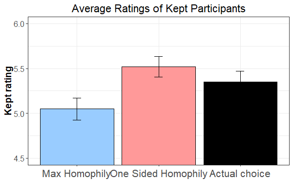

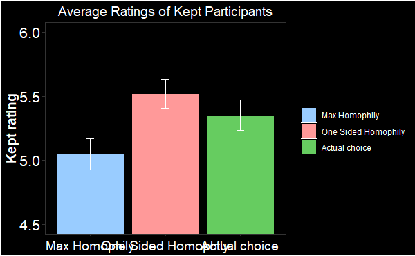

### 4 - stickiness of users

```r
#add a map function insted of creating three codes
stickCounter = function (df, keptVar, id=quo(subject_id), trial = quo(trial)){
  keptVar = enquo(keptVar)
  df %>%
    select(!!id, !!trial,!!keptVar)%>% #select a few variable
    mutate(id =!!keptVar,
           id_above= lag(!!keptVar),#variable and the one above
           id_below= lead(!!keptVar)) %>% #variable and the one below
    mutate(compare_above=(id==id_above),
           kept=(id==id_below)) %>%   #compare these - true false.
    replace_na(list(compare_above = 0))  %>%   # convert to 01
    replace_na(list(kept = 0))  %>%   # convert to 01
    group_by(subject_id,!!keptVar) %>%
    mutate(sticky = cumsum(compare_above))%>%
    ungroup()%>%
    select(subject_id, trial, sticky, kept)
}
a1=stickCounter(d,a1_id)
a2=stickCounter(d,a2_id)
a3=stickCounter(d,a3_id)
a4=stickCounter(d,a4_id)
a5=stickCounter(d,a5_id)
a6=stickCounter(d,a6_id)
colnames(a1)= c("subject_id","trial","a1_sticky","a1_decisionKeep")
colnames(a2)= c("subject_id","trial","a2_sticky","a2_decisionKeep")
colnames(a3)= c("subject_id","trial","a3_sticky","a3_decisionKeep")
colnames(a4)= c("subject_id","trial","a4_sticky","a4_decisionKeep")
colnames(a5)= c("subject_id","trial","a5_sticky","a5_decisionKeep")
colnames(a6)= c("subject_id","trial","a6_sticky","a6_decisionKeep")
d= left_join(d,a1,by=c("subject_id","trial")); rm(a1)
d= left_join(d,a2,by=c("subject_id","trial")); rm(a2)
d= left_join(d,a3,by=c("subject_id","trial")); rm(a3)
d= left_join(d,a4,by=c("subject_id","trial")); rm(a4)
d= left_join(d,a5,by=c("subject_id","trial")); rm(a5)
d= left_join(d,a6,by=c("subject_id","trial")); rm(a6)
q = d%>%
  select (subject_id,trial,condition, stimulus,subject_rating,a1_rating,a2_rating,a3_rating,a4_rating,a5_rating,a6_rating, ends_with("sticky"),ends_with("decisionKeep"))%>%
  gather(question, value, -subject_id,-trial,-condition,-stimulus,-subject_rating)%>%
  separate(question, into = c("agent", "question"), sep ="\\_")%>%
  separate(agent, into = c("removeThis","agent"),sep=1)%>%
  select (-removeThis)%>%
  spread(question,value)%>%
  mutate(stickyBinary =ifelse(sticky>=1,1,0))
q$dist = q$rating-q$subject_rating
```

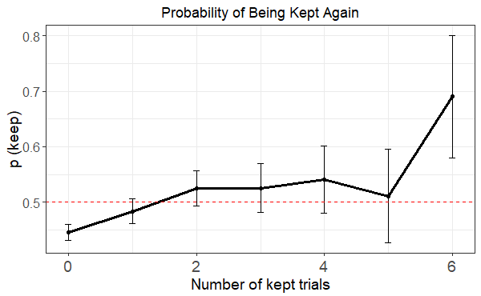

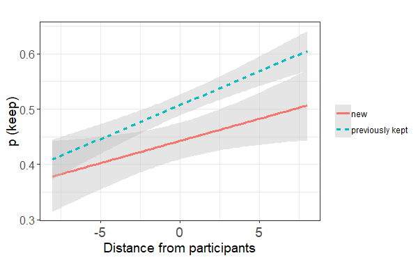

### sentiment Analysis

```r
cor.test(s$rating,s$sentNeg)
```

```
    Pearson's product-moment correlation

data:  s$rating and s$sentNeg
t = -25.009, df = 9770, p-value < 2.2e-16
alternative hypothesis: true correlation is not equal to 0
95 percent confidence interval:
 -0.2638317 -0.2265618
sample estimates:
       cor
-0.2452874
```

```r
# I need to restructure the files in order to get this ansswer
```

### word nuber as predictor

```r
wc = d %>%
  select(subject_id,condition,stimulus,subject_rating,starts_with("kept"),starts_with("elim"))%>%
  gather(key,value, -subject_id,-condition,-stimulus, -subject_rating)%>%
  separate(key, into = c("elimKeep", "number", "question"), sep ="\\_")%>%
  spread(question, value)%>%
  mutate(wordCount = sapply(gregexpr("[[:alpha:]]+", title), function(x) sum(x > 0)))

wc$elimKeep= factor (wc$elimKeep)
wc$elimKeep = ifelse (wc$elimKeep=="elim",0,1)
wc$rating=as.integer(wc$rating)

r = glmer (elimKeep~ condition*wordCount+(1|subject_id),wc);summary(r)


wc%>%
  group_by(condition) %>%
  do(print(summary((glmer(elimKeep~ log(wordCount)+rating+(1|subject_id),family=binomial, data=.)))))


wc%>%
  group_by(condition) %>%
  do(print(summary((lmer(rating~ wordCount+(1|subject_id), data=.)))))


r = lmer (rating~ log(wordCount)+(1|subject_id),wc);summary(r)

rm (wc)
```

#### aditional analysis

```r
robb = d%>%
  #slice (1:10)%>%
  arrange(subject_id, trial)%>%
  select(condition,subject_id, trial, ends_with("rating"), -starts_with("a"))%>%
  mutate(meanKeptPrevious = lag((kept_1_rating+kept_2_rating+kept_3_rating)/3))%>%
  mutate(meanElimPrevious = lag((elim_1_rating+elim_2_rating+elim_3_rating)/3))%>%
  mutate(meanPrevious = (meanKeptPrevious+meanElimPrevious)/2)


r= lmer (subject_rating~meanKeptPrevious+ (1|subject_id), robb) ;summary(r)

r= lmer (subject_rating~meanElimPrevious+ (1|subject_id), robb) ;summary(r)

r= lmer (subject_rating~meanPrevious+ (1|subject_id), robb) ;summary(r)
```

```r
#look at the absolute value compare elim v keep
#r = lmer (peerDif~ elimKeep+(1|subject_id), sl) ; summary (r)


dfc <- summarySE(subset(dl,condition == "select" & elimKeep=="kept"), measurevar="peerDif", groupvars=c("elimKeep","subject_id"), na.rm = T)
```

## graphs to presentation

```r
dfc <- summarySE(dl, measurevar="peerDif", groupvars=c("elimKeep","condition"), na.rm = T)


dfc$elimKeep=factor(dfc$elimKeep, labels = c("Eliminated", "Kept"))

#dfc$peerDif[3] = .30
pd <- position_dodge(0)
g=ggplot(dfc, aes(x=condition, y=peerDif, fill=elimKeep)) +
  geom_bar(position='dodge', stat="identity", colour="black" ) +
  labs(title=" Difference between kept users and the participant")+
  guides(fill=guide_legend(title=NULL))+
  theme_bw()+
  theme(plot.background = element_rect(fill = "black"),
        panel.background = element_rect(fill = 'black'),
        panel.border = element_blank(),
        panel.grid = element_blank(),
        legend.background= element_rect(fill="black", colour=NA),
        legend.text = element_text(colour = 'white'),
        plot.title = element_text(size = rel(1.3),hjust =.5, colour = 'white'),
        axis.title.y = element_text(face="bold",  size=14,colour = "white"),
        axis.text.x  = element_text( vjust=0.5, size=18,colour = "white"),
        axis.text.y  = element_text( vjust=0.5, size=16,colour = "white"),
        axis.title.x = element_blank()) +
  geom_errorbar(aes(ymin=peerDif-ci, ymax=peerDif+ci),
                  width=.1,position=position_dodge(.9),colour='white')+
  labs(title = "Peer Emotions in Relation to Participant Emotions",
       x = "",
       y = "")+
  scale_fill_manual(values=c("#99CCFF", "#FF9999", "#000000"))+
  geom_vline(xintercept = 1.5,linetype="dashed", color = "white")+
  geom_hline(yintercept = 0,linetype= 'dashed', color = "white")+
  annotate("text", x = 1.6, y = -1.6, label = "Less Emotional",colour ='white', size = 4.5)+
  annotate("text", x = 1.6, y = 1.6, label = "More Emotional", colour = 'white', size = 4.5)+
  coord_flip(ylim=c(-2, 2));g
```

```r
dfc <- summarySE(dl, measurevar="subject_rating", groupvars=c("condition", "trial"), na.rm = T)

g = (ggplot(dfc,aes(x=trial, y=subject_rating ,fill = condition,colour=condition))
  + geom_point(shape =1)
  #+ geom_errorbar(aes(ymin=subject_rating-ci, ymax=subject_rating+ci), width=.1)
  +stat_smooth(aes(linetype=condition, colour =condition),
              size =1.2, method='lm',fill = "grey",
              se = T, na.rm =T)
  #+geom_point()
  +scale_y_continuous(limits = c(4.5, 6))
  +theme_bw()
  +theme(plot.background = element_rect(fill = "black"),
        panel.background = element_rect(fill = 'black'),
        #panel.border = element_blank(),
        panel.grid = element_blank(),
        legend.background= element_rect(fill="black", colour=NA),
        legend.text = element_text(colour = 'white'),
        plot.title = element_text(size = rel(1.3),hjust =.5, colour = 'white'),
        axis.title.y = element_text(face="bold",  size=14,colour = "white"),
        axis.text.x  = element_text( vjust=0.5, size=18,colour = "white"),
        axis.text.y  = element_text( vjust=0.5, size=16,colour = "white"),
        axis.title.x = element_text(face="bold",  size=14,colour = "white"))
  +scale_fill_manual(values=c("#99CCFF", "#FF9999", "#000000"))

  +labs(title = "Participant Emotions per Trial Number", x = "Trial Number", y = "Emotion Ratings"));g
```

```r
s=subset(s,agent != "subject")
write.csv(s,"sentiment_value.csv")

ak = d%>%select (trial,ends_with("id"),-starts_with("elim"))

write.csv(ak, "PeerIds.csv")
```